IE 582 : Statistical Learning for Data Mining

Homework 1

Prof. Mustafa Gökçe Baydoğan

Doğa Erçin

2021402000

The goal of this project is to improve the design process for high-frequency antennas, especially those needed for 5G technology, which are used in communication systems. Achieving effective antenna performance across particular frequency bands is crucial, but predicting important characteristics, like the S11 parameter, which shows radiation efficiency and return loss, requires computationally expensive traditional electromagnetic simulations. Machine learning techniques have gained popularity as a way to model the intricate relationship between antenna geometry and the S-parameters, potentially reducing computation time and resource requirements, given the extensive trial and error frequently needed to optimize antenna design.

read files

```r
input <- read.csv("hw1_input.csv")
img <- read.csv("hw1_img.csv")
real <- read.csv("hw1_real.csv")
```

In order to perform a good analysis, we first need to clean and arrange the data so that we can use it in the training of our model. For the sake of simplicity, I will analyse the relationships of real and imaginary parts of the electromagnetic results seperately.

Clean the training data check if there are any missing values

```r
colSums(is.na(input))
```

```
##                            length.of.patch
##                                          0
##                             width.of.patch
##                                          0
##                            height.of.patch
##                                          0
##                        height.of.substrate
##                                          0
##              height.of.solder.resist.layer
##                                          0
##                        radius.of.the.probe
##                                          0
##                                      c_pad
##                                          0
##                                  c_antipad
##                                          0
##                                    c_probe
##                                          0
##           dielectric.constant.of.substrate
##                                          0
## dielectric.constant.of.solder.resist.layer
##                                          0
```

```r
colSums(is.na(img))
```

```
##   X0   X1   X2   X3   X4   X5   X6   X7   X8   X9  X10  X11  X12  X13  X14  X15
##    0    0    0    0    0    0    0    0    0    0    0    0    0    0    0    0
##  X16  X17  X18  X19  X20  X21  X22  X23  X24  X25  X26  X27  X28  X29  X30  X31
##    0    0    0    0    0    0    0    0    0    0    0    0    0    0    0    0
##  X32  X33  X34  X35  X36  X37  X38  X39  X40  X41  X42  X43  X44  X45  X46  X47
##    0    0    0    0    0    0    0    0    0    0    0    0    0    0    0    0
##  X48  X49  X50  X51  X52  X53  X54  X55  X56  X57  X58  X59  X60  X61  X62  X63
##    0    0    0    0    0    0    0    0    0    0    0    0    0    0    0    0
##  X64  X65  X66  X67  X68  X69  X70  X71  X72  X73  X74  X75  X76  X77  X78  X79
##    0    0    0    0    0    0    0    0    0    0    0    0    0    0    0    0
##  X80  X81  X82  X83  X84  X85  X86  X87  X88  X89  X90  X91  X92  X93  X94  X95
##    0    0    0    0    0    0    0    0    0    0    0    0    0    0    0    0
##  X96  X97  X98  X99 X100 X101 X102 X103 X104 X105 X106 X107 X108 X109 X110 X111
##    0    0    0    0    0    0    0    0    0    0    0    0    0    0    0    0
## X112 X113 X114 X115 X116 X117 X118 X119 X120 X121 X122 X123 X124 X125 X126 X127
##    0    0    0    0    0    0    0    0    0    0    0    0    0    0    0    0
## X128 X129 X130 X131 X132 X133 X134 X135 X136 X137 X138 X139 X140 X141 X142 X143
##    0    0    0    0    0    0    0    0    0    0    0    0    0    0    0    0
## X144 X145 X146 X147 X148 X149 X150 X151 X152 X153 X154 X155 X156 X157 X158 X159
##    0    0    0    0    0    0    0    0    0    0    0    0    0    0    0    0
## X160 X161 X162 X163 X164 X165 X166 X167 X168 X169 X170 X171 X172 X173 X174 X175
##    0    0    0    0    0    0    0    0    0    0    0    0    0    0    0    0
## X176 X177 X178 X179 X180 X181 X182 X183 X184 X185 X186 X187 X188 X189 X190 X191
##    0    0    0    0    0    0    0    0    0    0    0    0    0    0    0    0
## X192 X193 X194 X195 X196 X197 X198 X199 X200
##    0    0    0    0    0    0    0    0    0
```

```r
colSums(is.na(real))
```

```
##   X0   X1   X2   X3   X4   X5   X6   X7   X8   X9  X10  X11  X12  X13  X14  X15
##    0    0    0    0    0    0    0    0    0    0    0    0    0    0    0    0
##  X16  X17  X18  X19  X20  X21  X22  X23  X24  X25  X26  X27  X28  X29  X30  X31
##    0    0    0    0    0    0    0    0    0    0    0    0    0    0    0    0
##  X32  X33  X34  X35  X36  X37  X38  X39  X40  X41  X42  X43  X44  X45  X46  X47
##    0    0    0    0    0    0    0    0    0    0    0    0    0    0    0    0
##  X48  X49  X50  X51  X52  X53  X54  X55  X56  X57  X58  X59  X60  X61  X62  X63
##    0    0    0    0    0    0    0    0    0    0    0    0    0    0    0    0
##  X64  X65  X66  X67  X68  X69  X70  X71  X72  X73  X74  X75  X76  X77  X78  X79
##    0    0    0    0    0    0    0    0    0    0    0    0    0    0    0    0
##  X80  X81  X82  X83  X84  X85  X86  X87  X88  X89  X90  X91  X92  X93  X94  X95
##    0    0    0    0    0    0    0    0    0    0    0    0    0    0    0    0
##  X96  X97  X98  X99 X100 X101 X102 X103 X104 X105 X106 X107 X108 X109 X110 X111
##    0    0    0    0    0    0    0    0    0    0    0    0    0    0    0    0
## X112 X113 X114 X115 X116 X117 X118 X119 X120 X121 X122 X123 X124 X125 X126 X127
##    0    0    0    0    0    0    0    0    0    0    0    0    0    0    0    0
## X128 X129 X130 X131 X132 X133 X134 X135 X136 X137 X138 X139 X140 X141 X142 X143
##    0    0    0    0    0    0    0    0    0    0    0    0    0    0    0    0
## X144 X145 X146 X147 X148 X149 X150 X151 X152 X153 X154 X155 X156 X157 X158 X159
##    0    0    0    0    0    0    0    0    0    0    0    0    0    0    0    0
## X160 X161 X162 X163 X164 X165 X166 X167 X168 X169 X170 X171 X172 X173 X174 X175
##    0    0    0    0    0    0    0    0    0    0    0    0    0    0    0    0
## X176 X177 X178 X179 X180 X181 X182 X183 X184 X185 X186 X187 X188 X189 X190 X191
##    0    0    0    0    0    0    0    0    0    0    0    0    0    0    0    0
## X192 X193 X194 X195 X196 X197 X198 X199 X200
##    0    0    0    0    0    0    0    0    0
```

Check if all variables are in range if not, replace them with an appropriate value, or discard the row completely

For columns with values out of range, replacement is done based on the column’s variance. If the variance is low (less than 0.3), the mean is used; otherwise, the median is chosen as the replacement value.

```r
ranges <- matrix(c(1.8,5.2,1.8,5.2,0.01,0.04,0.1,0.8,0.02,0.1,0.015,0.05,0,0.025,0.025,0.1,0.05,0.45,2,5,2,5),nrow=11,ncol=2,byrow=TRUE)

#discard the row if 3+ columns are out of range
out_of_range_count <- apply(input, 1, function(row) {
  sum(sapply(1:length(row), function(i) {
    row[i] < ranges[i, 1] || row[i] > ranges[i, 2]
  }))
})
input_cleaned <- input[out_of_range_count < 4, ]
cat("Number of rows removed:", nrow(input) - nrow(input_cleaned), "\n")
```

```
## Number of rows removed: 0
```

Due to the nature of the features, any values that are out of the given range should not be accepted! So, before an IQR analysis, I completely disregard out of range values and replace them with appropriate values. If the feature variance is small enough, I replace the outliers with the column mean; and if not, I replace it with the median to not be affected by the outliers. After that, I perform an IQR analysis and do the same replacement

```r
changes_per_column <- rep(0,ncol(input_cleaned))
changes_per_column_iqr <- rep(0,ncol(input_cleaned))

for (i in 1:ncol(input_cleaned)) {
  min_val <- ranges[i, 1]
  max_val <- ranges[i, 2]
    col_var <- var(input_cleaned[[i]])
    if (col_var < 0.3){
      replacement <- mean(input_cleaned[[i]], na.rm = TRUE)
    }else{
      replacement <- median(input_cleaned[[i]], na.rm = TRUE)
    }

  # Replace values outside the range with the replacement
  out_of_range <- input_cleaned[[i]] < min_val | input_cleaned[[i]] > max_val
  changes_per_column[i] <- sum(out_of_range)
  input_cleaned[[i]][out_of_range] <- replacement

  iqr<- IQR(input_cleaned[,i])*(1.5)
  lower <-quantile(input_cleaned[,i], prob=0.25)
  upper <- quantile(input_cleaned[,i], prob=0.75)
  out_of_range_iqr <- input_cleaned[[i]] < lower-iqr | input_cleaned[[i]] > upper+iqr
  changes_per_column_iqr[i] <- sum(out_of_range_iqr)
  input_cleaned[[i]][out_of_range_iqr] <- replacement
}

in_range <- sapply(1:ncol(input_cleaned), function(i) {
  min_val <- ranges[i, 1]
  max_val <- ranges[i, 2]
all(input_cleaned[[i]] >= min_val & input_cleaned[[i]] <= max_val)
})

if (all(in_range)) {
  cat("All out-of-range values have been replaced with the replacement.\n")
  print(changes_per_column)
  print(changes_per_column_iqr)
} else {
  cat("Some parameters still have values outside their ranges.\n")
  print(changes_per_column)
  print(which(!in_range))
}
```

```
## All out-of-range values have been replaced with the replacement.
##  [1] 0 0 0 0 0 0 0 0 0 0 0
##  [1] 0 0 0 0 0 0 0 0 0 0 0
```

Then I check the correlation between variables to have a better understanding about the relationships between the variables. I obtain a 11x11 matrix which has pairwise covariance values.It seems, that the strongest relation is between the width of patch and height of substrate, close to %92 and positively correlated.

```r
cor(input)
```

```
##                                            length.of.patch width.of.patch
## length.of.patch                                1.000000000    -0.11417384
## width.of.patch                                -0.114173838     1.00000000
## height.of.patch                               -0.026031974     0.09172574
## height.of.substrate                           -0.064343925     0.92373918
## height.of.solder.resist.layer                  0.044501770    -0.02105555
## radius.of.the.probe                           -0.069904535     0.03567518
## c_pad                                         -0.005560154    -0.04419845
## c_antipad                                     -0.009627304    -0.01335778
## c_probe                                        0.081734722     0.02999903
## dielectric.constant.of.substrate              -0.037447806     0.44219338
## dielectric.constant.of.solder.resist.layer    -0.014495695     0.03874586
##                                            height.of.patch height.of.substrate
## length.of.patch                                -0.02603197        -0.064343925
## width.of.patch                                  0.09172574         0.923739177
## height.of.patch                                 1.00000000         0.082833400
## height.of.substrate                             0.08283340         1.000000000
## height.of.solder.resist.layer                   0.03604491        -0.011870246
## radius.of.the.probe                             0.03068912         0.017410148
## c_pad                                           0.00242201        -0.031570678
## c_antipad                                       0.03758257        -0.009432011
## c_probe                                         0.03159241         0.044165512
## dielectric.constant.of.substrate               -0.04431754         0.459846618
## dielectric.constant.of.solder.resist.layer     -0.03776888         0.002420837
##                                            height.of.solder.resist.layer
## length.of.patch                                               0.04450177
## width.of.patch                                               -0.02105555
## height.of.patch                                               0.03604491
## height.of.substrate                                          -0.01187025
## height.of.solder.resist.layer                                 1.00000000
## radius.of.the.probe                                          -0.01275622
## c_pad                                                        -0.01804425
## c_antipad                                                    -0.01707067
## c_probe                                                       0.02484211
## dielectric.constant.of.substrate                             -0.01096653
## dielectric.constant.of.solder.resist.layer                   -0.03840494
##                                            radius.of.the.probe        c_pad
## length.of.patch                                  -0.0699045348 -0.005560154
## width.of.patch                                    0.0356751757 -0.044198447
## height.of.patch                                   0.0306891240  0.002422010
```

[output cut: 29 more lines]

```
## c_probe                                                          0.01564016
## dielectric.constant.of.substrate                                 1.00000000
## dielectric.constant.of.solder.resist.layer                       0.06040161
##                                            dielectric.constant.of.solder.resist.layer
## length.of.patch                                                          -0.014495695
## width.of.patch                                                            0.038745861
## height.of.patch                                                          -0.037768883
## height.of.substrate                                                       0.002420837
## height.of.solder.resist.layer                                            -0.038404940
## radius.of.the.probe                                                       0.007523673
## c_pad                                                                     0.015283927
## c_antipad                                                                 0.067820517
## c_probe                                                                  -0.029100791
## dielectric.constant.of.substrate                                          0.060401607
## dielectric.constant.of.solder.resist.layer                                1.000000000
```

Dimensionality Reduction with PCA We want to make sure the data is scaled before we can do a PCA analysis:

```r
input_scaled <- scale(input_cleaned)
pca_result <- princomp(input_scaled, cor=T)
summary(pca_result,loadings=T)
```

```
## Importance of components:
##                           Comp.1    Comp.2    Comp.3     Comp.4     Comp.5
## Standard deviation     1.5095325 1.1035356 1.0489863 1.02800587 1.00527544
## Proportion of Variance 0.2071535 0.1107083 0.1000338 0.09607237 0.09187079
## Cumulative Proportion  0.2071535 0.3178617 0.4178956 0.51396794 0.60583873
##                            Comp.6     Comp.7     Comp.8     Comp.9    Comp.10
## Standard deviation     0.98642834 0.97069535 0.94771083 0.89854601 0.80083052
## Proportion of Variance 0.08845826 0.08565904 0.08165053 0.07339863 0.05830268
## Cumulative Proportion  0.69429699 0.77995603 0.86160656 0.93500519 0.99330787
##                            Comp.11
## Standard deviation     0.271317885
## Proportion of Variance 0.006692127
## Cumulative Proportion  1.000000000
##
## Loadings:
##                                            Comp.1 Comp.2 Comp.3 Comp.4 Comp.5
## length.of.patch                             0.101  0.315  0.370  0.377  0.410
## width.of.patch                             -0.624
## height.of.patch                                          -0.620  0.393
## height.of.substrate                        -0.624
## height.of.solder.resist.layer                      0.266         0.511 -0.125
## radius.of.the.probe                                      -0.548 -0.454  0.219
## c_pad                                             -0.266 -0.145  0.178  0.580
## c_antipad                                         -0.559         0.374  0.128
## c_probe                                            0.565        -0.151  0.488
## dielectric.constant.of.substrate           -0.445         0.256
## dielectric.constant.of.solder.resist.layer        -0.351  0.255 -0.185  0.420
##                                            Comp.6 Comp.7 Comp.8 Comp.9 Comp.10
## length.of.patch                                    0.253  0.454  0.406
## width.of.patch                                                          0.329
## height.of.patch                                    0.490 -0.318  0.217 -0.243
## height.of.substrate                                                     0.305
## height.of.solder.resist.layer               0.460 -0.647 -0.110
## radius.of.the.probe                         0.305 -0.213  0.491  0.240
## c_pad                                      -0.548 -0.430 -0.174  0.140
## c_antipad                                   0.172  0.138  0.416 -0.549
## c_probe                                            0.103 -0.129 -0.619
## dielectric.constant.of.substrate                                       -0.849
## dielectric.constant.of.solder.resist.layer  0.592        -0.460  0.146
##                                            Comp.11
## length.of.patch
## width.of.patch                              0.704
## height.of.patch
## height.of.substrate                        -0.708
## height.of.solder.resist.layer
## radius.of.the.probe
## c_pad
## c_antipad
## c_probe
## dielectric.constant.of.substrate
## dielectric.constant.of.solder.resist.layer
```

As seen from the cumulative proportion data, we may reduce the dimensions up to the point at which we preserve at approximately 85% of the variance in data. In this case, we can choose to have 8 components.

The strong correlation we drew from the correlations matrix is visible in the component equations here. The coefficients of width of patch and height of substrate are the same in the first 8 components, which contains 86% of the variance information.

For instance, the first component of the PCA is as follows: comp1= 0.101x1-0.624x2-0.624x4-0.445x10 This index is positively correlated with the length of patch(x1), but negatively correlated with the other variables that exist in the equation.

```r
pca_loadings <- pca_result$loadings
pca_equations <- pca_loadings[,1:8]
data_after_pca <- input_scaled %*% pca_equations
```

The matrix pca_equations store 86.16% of the variance in data information, and our dimension is now reduced to 8 from 11.

-Regression analysis

It would be computationaly very expensive to perform a regression fit for all of the 201 frequencies that are given in the data. Therefore, we have to choose some of them to use in our analysis. For example, we could choose the frequencies which differ strongly from the others.

To find them out, I compared the column mean with the mean of the 5 surrounding columns, and if it is significantly different from the neighborhood mean, I included that frequency in my analysis.

```r
selected_cols <- c(rep(0,ncol(real)))

for (i in 1:ncol(real)){
  if (i <=2){
    ref_mean <- (mean(c(real[[1]],real[[2]],real[[3]],real[[4]],real[[5]])))
  } else if (i<=199){
    ref_mean <- mean(c(real[[i-2]],real[[i-1]],real[[i]],real[[i+1]],real[[i+2]]))
  }else{
    ref_mean <- mean(c(real[[i-4]],real[[i-3]],real[[i]],real[[i-2]],real[[i-1]]))
  }

  m <- mean(real[[i]])
  if (m > (0.995)*ref_mean | m < (1.005)*ref_mean){
    selected_cols[i]<-1
  }else{
    selected_cols[i]<-0
  }
}

n_selected_columns <- sum(selected_cols)
cat("The number of selected columns are:", n_selected_columns,"\n")
```

```
## The number of selected columns are: 4
```

```r
print(selected_cols)
```

```
##   [1] 1 1 0 0 0 0 0 0 0 0 0 0 0 0 0 0 0 0 0 0 0 0 0 0 0 0 0 0 0 0 0 0 0 0 0 0 0
##  [38] 0 0 0 0 0 0 0 0 0 0 0 0 0 0 0 0 0 0 0 0 0 0 0 0 0 0 0 0 0 0 0 0 0 0 0 0 0
##  [75] 0 0 0 0 0 0 0 0 0 0 0 0 0 0 0 0 0 0 0 0 0 0 0 0 0 0 0 0 0 0 0 0 0 0 0 0 0
## [112] 0 0 0 0 0 0 0 0 0 0 0 0 0 0 0 0 0 0 0 0 0 0 0 0 0 0 0 0 0 0 0 0 0 0 0 0 0
## [149] 0 0 0 0 0 0 0 0 0 0 0 0 0 0 0 0 0 0 0 0 0 0 0 0 0 0 0 0 0 0 0 0 0 0 0 0 0
## [186] 0 0 0 0 0 0 0 0 0 0 0 0 0 0 1 1
```

Because the selected columns with this method are accumulated in the lower and higher frequencies, I will add some columns randomly to investigate some columns from the middle frequencies as well.

```r
set.seed(123)

random_positions <- sample(1:201, 2)
selected_cols[random_positions] <- 1
selected_cols[2] <- 0
selected_cols[200] <- 0
print(selected_cols)
```

```
##   [1] 1 0 0 0 0 0 0 0 0 0 0 0 0 0 0 0 0 0 0 0 0 0 0 0 0 0 0 0 0 0 0 0 0 0 0 0 0
##  [38] 0 0 0 0 0 0 0 0 0 0 0 0 0 0 0 0 0 0 0 0 0 0 0 0 0 0 0 0 0 0 0 0 0 0 0 0 0
##  [75] 0 0 0 0 0 0 0 0 0 0 0 0 0 0 0 0 0 0 0 0 0 0 0 0 0 0 0 0 0 0 0 0 0 0 0 0 0
## [112] 0 0 0 0 0 0 0 0 0 0 0 0 0 0 0 0 0 0 0 0 0 0 0 0 0 0 0 0 0 0 0 0 0 0 0 0 0
## [149] 0 0 0 0 0 0 0 0 0 0 1 0 0 0 0 0 0 0 0 0 0 0 0 0 0 0 0 0 0 0 1 0 0 0 0 0 0
## [186] 0 0 0 0 0 0 0 0 0 0 0 0 0 0 0 1
```

```r
real_new <- real[,selected_cols==1]
img_new <- img[,selected_cols==1]
```

We will use these 4 columns for the rest of the analysis. For these 4 columns, I perform linear regressions to train the model.

Linear regression: First, we sepearate the big block of data into two so that we can use it for training and testing purposes seperately.

```r
y1_all<-c(real_new[[1]])
y2_all<-c(real_new[[2]])
y3_all<-c(real_new[[3]])
y4_all<-c(real_new[[4]])
df_all <- as.data.frame(input_cleaned)
df <- df_all[1:193,]
df_test <- df_all[193:385,]
y1_test <- y1_all[193:385]
y2_test <- y2_all[193:385]
y3_test <- y3_all[193:385]
y4_test <- y4_all[193:385]
y1<-y1_all[1:193]
y2<-y2_all[1:193]
y3<-y3_all[1:193]
y4<-y4_all[1:193]

real_test <- real_new[193:385,]
img_test <- img_new[193:385,]
real_new <- real_new[1:193,]
img_new<- img_new[1:193,]
```

```r
regression1 <-lm(y1~., df)
summary(regression1)
```

```
##
## Call:
## lm(formula = y1 ~ ., data = df)
##
## Residuals:
##      Min       1Q   Median       3Q      Max
## -0.70197 -0.17530 -0.07598  0.08315  1.61302
##
## Coefficients:
##                                             Estimate Std. Error t value
## (Intercept)                                -0.963607   0.271968  -3.543
## length.of.patch                            -0.028155   0.026047  -1.081
## width.of.patch                              0.061846   0.055870   1.107
## height.of.patch                            -1.866794   2.823978  -0.661
## height.of.substrate                         2.259139   0.239864   9.418
## height.of.solder.resist.layer               0.036010   1.034325   0.035
## radius.of.the.probe                        -1.465030   2.304426  -0.636
## c_pad                                      -1.556409   3.354250  -0.464
## c_antipad                                  -1.693991   1.105590  -1.532
## c_probe                                     0.314972   0.218788   1.440
## dielectric.constant.of.substrate            0.009158   0.032121   0.285
## dielectric.constant.of.solder.resist.layer -0.001633   0.028840  -0.057
##                                            Pr(>|t|)
## (Intercept)                                0.000503 ***
## length.of.patch                            0.281174
## width.of.patch                             0.269782
## height.of.patch                            0.509420
## height.of.substrate                         < 2e-16 ***
## height.of.solder.resist.layer              0.972266
## radius.of.the.probe                        0.525745
## c_pad                                      0.643197
## c_antipad                                  0.127218
## c_probe                                    0.151701
## dielectric.constant.of.substrate           0.775891
## dielectric.constant.of.solder.resist.layer 0.954895
## ---
## Signif. codes:  0 '***' 0.001 '**' 0.01 '*' 0.05 '.' 0.1 ' ' 1
##
## Residual standard error: 0.3312 on 181 degrees of freedom
## Multiple R-squared:  0.8313, Adjusted R-squared:  0.8211
## F-statistic: 81.11 on 11 and 181 DF,  p-value: < 2.2e-16
```

```r
regression2 <-lm(y2~., df)
summary(regression2)
```

```
##
## Call:
## lm(formula = y2 ~ ., data = df)
##
## Residuals:
##      Min       1Q   Median       3Q      Max
## -0.65890 -0.16315 -0.04564  0.12019  1.09757
##
## Coefficients:
##                                             Estimate Std. Error t value
## (Intercept)                                -1.262247   0.241042  -5.237
## length.of.patch                            -0.003663   0.023085  -0.159
## width.of.patch                              0.155464   0.049517   3.140
## height.of.patch                             0.628717   2.502861   0.251
## height.of.substrate                         1.381781   0.212589   6.500
## height.of.solder.resist.layer               0.236849   0.916711   0.258
## radius.of.the.probe                        -4.705997   2.042387  -2.304
## c_pad                                      -0.288317   2.972835  -0.097
## c_antipad                                  -0.825395   0.979872  -0.842
## c_probe                                    -0.201626   0.193909  -1.040
## dielectric.constant.of.substrate            0.027279   0.028468   0.958
## dielectric.constant.of.solder.resist.layer  0.028849   0.025560   1.129
##                                            Pr(>|t|)
## (Intercept)                                4.51e-07 ***
## length.of.patch                             0.87411
## width.of.patch                              0.00198 **
## height.of.patch                             0.80195
## height.of.substrate                        7.57e-10 ***
## height.of.solder.resist.layer               0.79642
## radius.of.the.probe                         0.02235 *
## c_pad                                       0.92285
## c_antipad                                   0.40070
## c_probe                                     0.29982
## dielectric.constant.of.substrate            0.33924
## dielectric.constant.of.solder.resist.layer  0.26053
## ---
## Signif. codes:  0 '***' 0.001 '**' 0.01 '*' 0.05 '.' 0.1 ' ' 1
##
## Residual standard error: 0.2935 on 181 degrees of freedom
## Multiple R-squared:  0.8054, Adjusted R-squared:  0.7936
## F-statistic: 68.09 on 11 and 181 DF,  p-value: < 2.2e-16
```

```r
regression3 <-lm(y3~., df)
summary(regression3)
```

```
##
## Call:
## lm(formula = y3 ~ ., data = df)
##
## Residuals:
##      Min       1Q   Median       3Q      Max
## -0.63494 -0.16057 -0.02715  0.13481  1.17491
##
## Coefficients:
##                                            Estimate Std. Error t value Pr(>|t|)
## (Intercept)                                -1.05259    0.22701  -4.637 6.76e-06
## length.of.patch                            -0.03530    0.02174  -1.623 0.106233
## width.of.patch                              0.17448    0.04663   3.742 0.000245
## height.of.patch                             1.34658    2.35711   0.571 0.568514
## height.of.substrate                         1.33259    0.20021   6.656 3.24e-10
## height.of.solder.resist.layer               0.39364    0.86333   0.456 0.648967
## radius.of.the.probe                        -5.92564    1.92345  -3.081 0.002387
## c_pad                                      -1.71402    2.79971  -0.612 0.541165
## c_antipad                                  -1.72829    0.92281  -1.873 0.062700
## c_probe                                    -0.17912    0.18262  -0.981 0.327986
## dielectric.constant.of.substrate            0.01933    0.02681   0.721 0.471816
## dielectric.constant.of.solder.resist.layer  0.02680    0.02407   1.113 0.267002
##
## (Intercept)                                ***
## length.of.patch
## width.of.patch                             ***
## height.of.patch
## height.of.substrate                        ***
## height.of.solder.resist.layer
## radius.of.the.probe                        **
## c_pad
## c_antipad                                  .
## c_probe
## dielectric.constant.of.substrate
## dielectric.constant.of.solder.resist.layer
## ---
## Signif. codes:  0 '***' 0.001 '**' 0.01 '*' 0.05 '.' 0.1 ' ' 1
##
## Residual standard error: 0.2764 on 181 degrees of freedom
## Multiple R-squared:  0.8289, Adjusted R-squared:  0.8185
## F-statistic: 79.73 on 11 and 181 DF,  p-value: < 2.2e-16
```

```r
regression4 <-lm(y4~., df)
summary(regression4)
```

```
##
## Call:
## lm(formula = y4 ~ ., data = df)
##
## Residuals:
##      Min       1Q   Median       3Q      Max
## -0.82125 -0.18188 -0.03373  0.14986  1.18220
##
## Coefficients:
##                                            Estimate Std. Error t value Pr(>|t|)
## (Intercept)                                -1.11290    0.24878  -4.473 1.36e-05
## length.of.patch                            -0.03178    0.02383  -1.334 0.183934
## width.of.patch                              0.20132    0.05111   3.939 0.000117
## height.of.patch                             1.71685    2.58323   0.665 0.507144
## height.of.substrate                         1.22252    0.21942   5.572 9.02e-08
## height.of.solder.resist.layer               1.16702    0.94615   1.233 0.219010
## radius.of.the.probe                        -6.25660    2.10797  -2.968 0.003402
## c_pad                                      -2.08838    3.06830  -0.681 0.496974
## c_antipad                                  -0.76793    1.01134  -0.759 0.448646
## c_probe                                    -0.34568    0.20014  -1.727 0.085834
## dielectric.constant.of.substrate            0.02721    0.02938   0.926 0.355569
## dielectric.constant.of.solder.resist.layer  0.01248    0.02638   0.473 0.636760
##
## (Intercept)                                ***
## length.of.patch
## width.of.patch                             ***
## height.of.patch
## height.of.substrate                        ***
## height.of.solder.resist.layer
## radius.of.the.probe                        **
## c_pad
## c_antipad
## c_probe                                    .
## dielectric.constant.of.substrate
## dielectric.constant.of.solder.resist.layer
## ---
## Signif. codes:  0 '***' 0.001 '**' 0.01 '*' 0.05 '.' 0.1 ' ' 1
##
## Residual standard error: 0.303 on 181 degrees of freedom
## Multiple R-squared:  0.8031, Adjusted R-squared:  0.7911
## F-statistic: 67.12 on 11 and 181 DF,  p-value: < 2.2e-16
```

The R-squared values for all the regressions are around 0.77-0.83, which provides a pretty good approximation. The R-squared values are similar for each regression model, with the first one being highest.

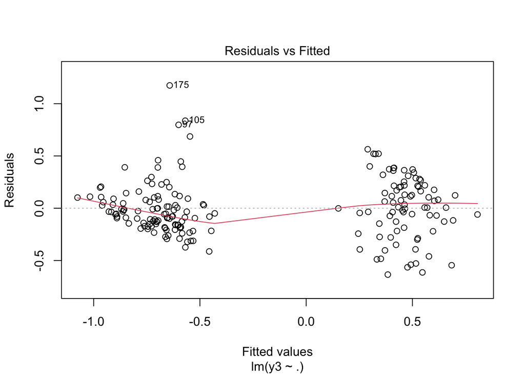

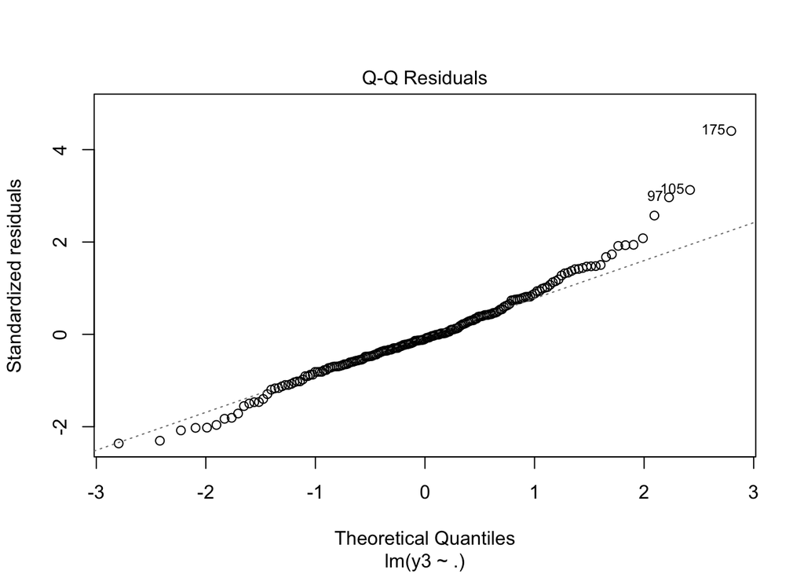

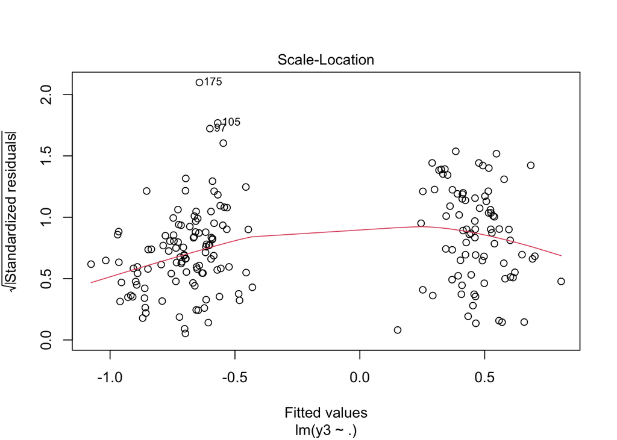

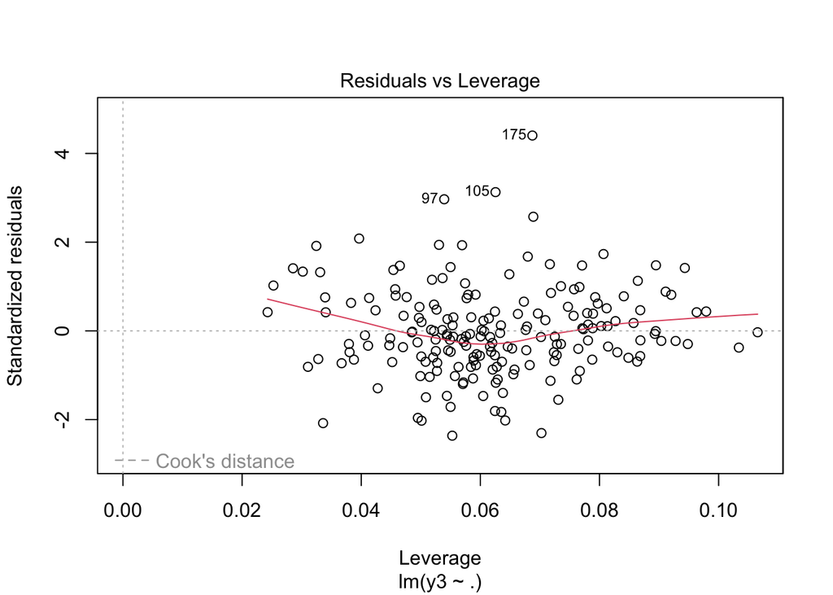

```r
plot(regression3)
```

In the Q-Q Residuals plot, a sharp deviation at the tail towards the right is observed. This may indicate potential skewness of the model. The small deviation at the left part of the graph is expected, since the distributions are expected to be close to normal and have small deviations at the ends.

The residuals vs. Fitted plot suggests that there is a pattern present. The points on the graph appear to be distributed above and below the graph randomly, but are accumulated in the left and right sides of the graph. This may indicate something that the model is missing, we may try adding some higher order terms.

Third regression:

```
Residuals:
     Min       1Q   Median       3Q      Max
-0.63494 -0.16057 -0.02715  0.13481  1.17491
```

```
Residuals:
     Min       1Q   Median       3Q      Max
-0.70197 -0.17530 -0.07598  0.08315  1.61302
```

This is not a very symmetric fit of the residuals, and it can indicate the accumulation of the residuals in one side.

Let us eliminate the variables so that only the significant variables are present:

```r
sign_vars<- c(2,4,6)
df_significant <- df[, sign_vars]
df_test_significant <- df_test[, sign_vars]
regression3 <-lm(y3~., data=df_significant)
summary(regression3)
```

```
##
## Call:
## lm(formula = y3 ~ ., data = df_significant)
##
## Residuals:
##      Min       1Q   Median       3Q      Max
## -0.70328 -0.15150 -0.05327  0.14884  1.23351
##
## Coefficients:
##                     Estimate Std. Error t value Pr(>|t|)
## (Intercept)         -1.18263    0.12383  -9.550  < 2e-16 ***
## width.of.patch       0.18882    0.04614   4.092 6.33e-05 ***
## height.of.substrate  1.32294    0.19477   6.792 1.39e-10 ***
## radius.of.the.probe -5.79194    1.91108  -3.031  0.00278 **
## ---
## Signif. codes:  0 '***' 0.001 '**' 0.01 '*' 0.05 '.' 0.1 ' ' 1
##
## Residual standard error: 0.2777 on 189 degrees of freedom
## Multiple R-squared:  0.8198, Adjusted R-squared:  0.8169
## F-statistic: 286.6 on 3 and 189 DF,  p-value: < 2.2e-16
```

After this analysis, I will try to improve the regression model with respect to the 3rd selected column, because of the better fit of the residuals.

Now, let us try a quadratic model with respect to the second component with significant and non-significant, since that one highly significant:

```r
model_quad <- lm(y3 ~ df[,1] + I(df[,2]^2) + df[,2] + df[,3] + df[,4] + df[,5] + df[,6] + df[,7] + df[,8] +df[,9]+df[,10]+df[,11], data=df)

summary(model_quad)
```

```
##
## Call:
## lm(formula = y3 ~ df[, 1] + I(df[, 2]^2) + df[, 2] + df[, 3] +
##     df[, 4] + df[, 5] + df[, 6] + df[, 7] + df[, 8] + df[, 9] +
##     df[, 10] + df[, 11], data = df)
##
## Residuals:
##     Min      1Q  Median      3Q     Max
## -0.6611 -0.1665 -0.0258  0.1345  1.1817
##
## Coefficients:
##              Estimate Std. Error t value Pr(>|t|)
## (Intercept)  -0.74020    0.40809  -1.814 0.071372 .
## df[, 1]      -0.03615    0.02177  -1.660 0.098586 .
## I(df[, 2]^2)  0.03228    0.03503   0.921 0.358113
## df[, 2]      -0.01764    0.21368  -0.083 0.934306
## df[, 3]       1.36550    2.35818   0.579 0.563280
## df[, 4]       1.14103    0.28870   3.952 0.000111 ***
## df[, 5]       0.34231    0.86548   0.396 0.692929
## df[, 6]      -6.14951    1.93953  -3.171 0.001788 **
## df[, 7]      -1.77132    2.80157  -0.632 0.528020
## df[, 8]      -1.73040    0.92320  -1.874 0.062501 .
## df[, 9]      -0.15337    0.18482  -0.830 0.407728
## df[, 10]      0.01857    0.02683   0.692 0.489719
## df[, 11]      0.02554    0.02412   1.059 0.291155
## ---
## Signif. codes:  0 '***' 0.001 '**' 0.01 '*' 0.05 '.' 0.1 ' ' 1
##
## Residual standard error: 0.2766 on 180 degrees of freedom
## Multiple R-squared:  0.8297, Adjusted R-squared:  0.8184
## F-statistic: 73.09 on 12 and 180 DF,  p-value: < 2.2e-16
```

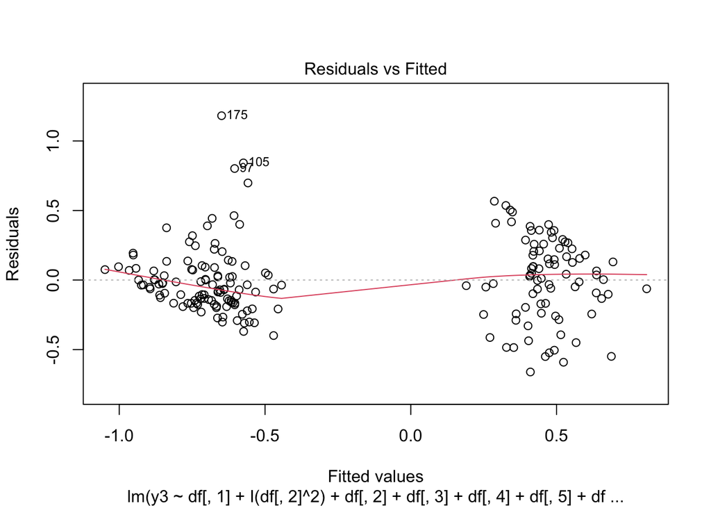

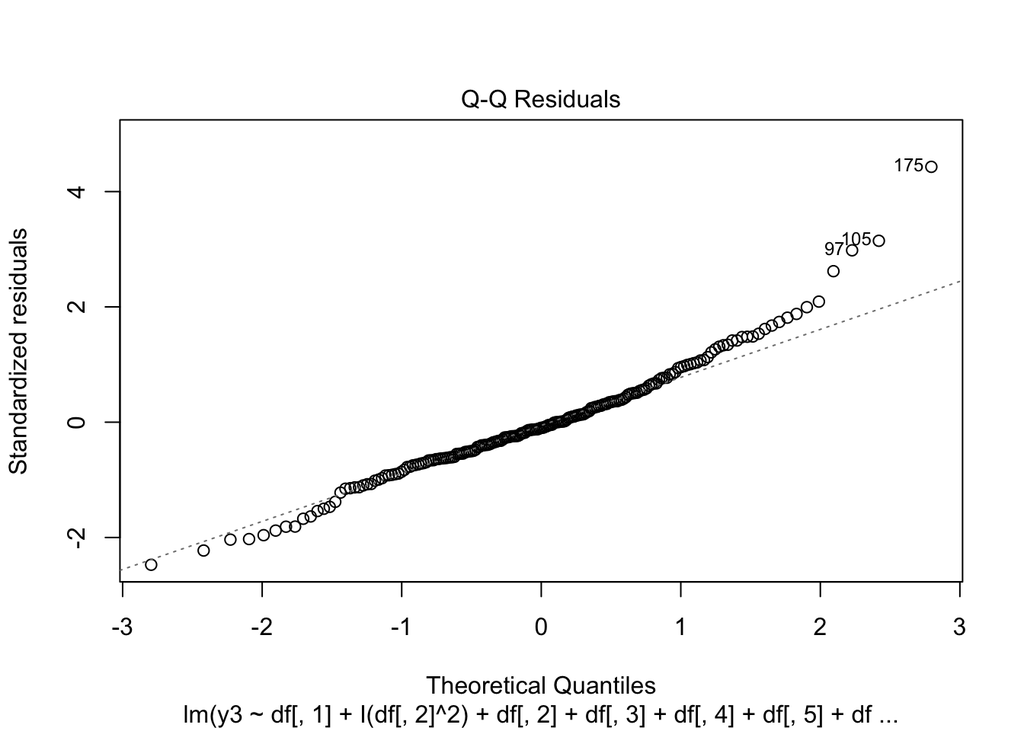

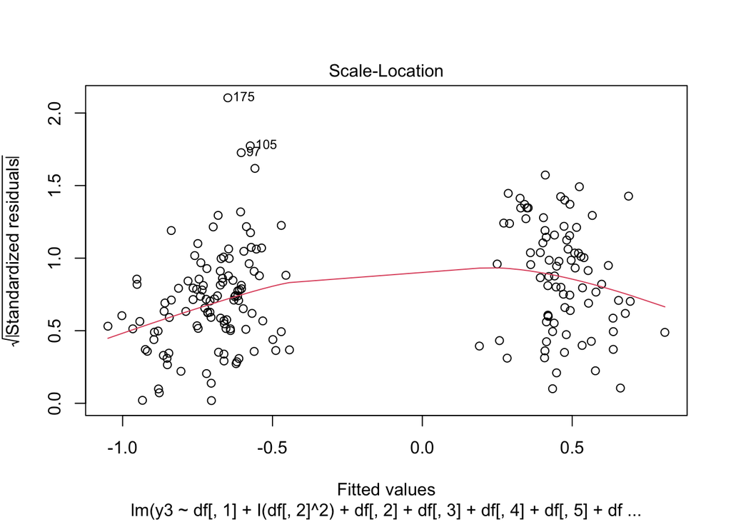

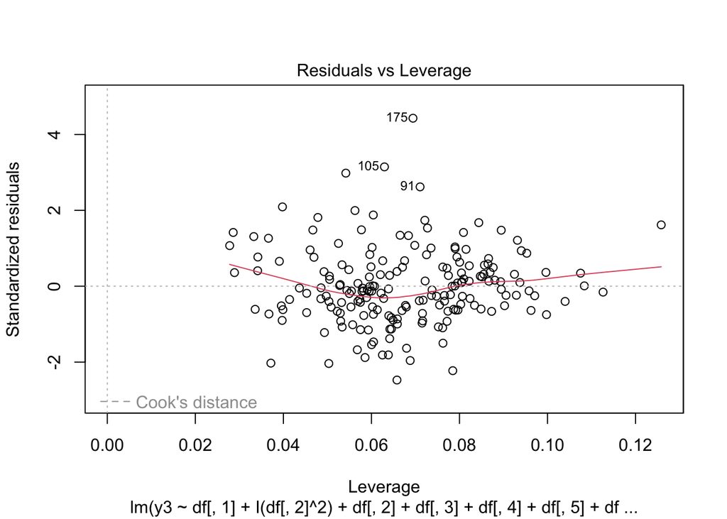

```r
plot(model_quad)
```

Let us try a cubic pattern:

```r
model_cubic <- lm(y3 ~ df[,1] + I(df[,2]^2) + I(df[,2]^3) + df[,2] + df[,3] + df[,4] + df[,5] + df[,6] + df[,7] + df[,8] +df[,9]+df[,10]+df[,11], data=df)
summary(model_cubic)
```

```
##
## Call:
## lm(formula = y3 ~ df[, 1] + I(df[, 2]^2) + I(df[, 2]^3) + df[,
##     2] + df[, 3] + df[, 4] + df[, 5] + df[, 6] + df[, 7] + df[,
##     8] + df[, 9] + df[, 10] + df[, 11], data = df)
##
## Residuals:
##      Min       1Q   Median       3Q      Max
## -0.63365 -0.16414 -0.01119  0.13977  1.16677
##
## Coefficients:
##              Estimate Std. Error t value Pr(>|t|)
## (Intercept)   0.79959    1.31014   0.610  0.54243
## df[, 1]      -0.03583    0.02174  -1.648  0.10112
## I(df[, 2]^2)  0.49270    0.37396   1.318  0.18935
## I(df[, 2]^3) -0.04356    0.03522  -1.237  0.21785
## df[, 2]      -1.51714    1.23121  -1.232  0.21948
## df[, 3]       1.30762    2.35519   0.555  0.57945
## df[, 4]       0.96732    0.32068   3.017  0.00293 **
## df[, 5]       0.38444    0.86488   0.445  0.65722
## df[, 6]      -6.10726    1.93699  -3.153  0.00190 **
## df[, 7]      -1.94055    2.80081  -0.693  0.48930
## df[, 8]      -1.69092    0.92240  -1.833  0.06844 .
## df[, 9]      -0.17259    0.18520  -0.932  0.35264
## df[, 10]      0.02034    0.02683   0.758  0.44934
## df[, 11]      0.02523    0.02409   1.047  0.29637
## ---
## Signif. codes:  0 '***' 0.001 '**' 0.01 '*' 0.05 '.' 0.1 ' ' 1
##
## Residual standard error: 0.2762 on 179 degrees of freedom
## Multiple R-squared:  0.8312, Adjusted R-squared:  0.8189
## F-statistic: 67.79 on 13 and 179 DF,  p-value: < 2.2e-16
```

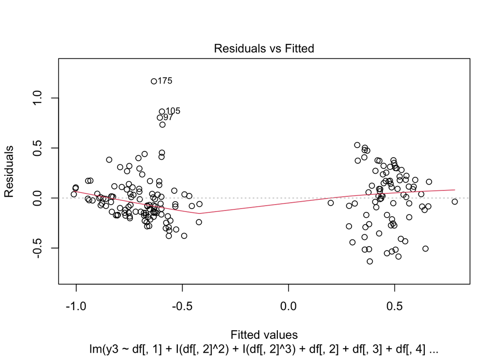

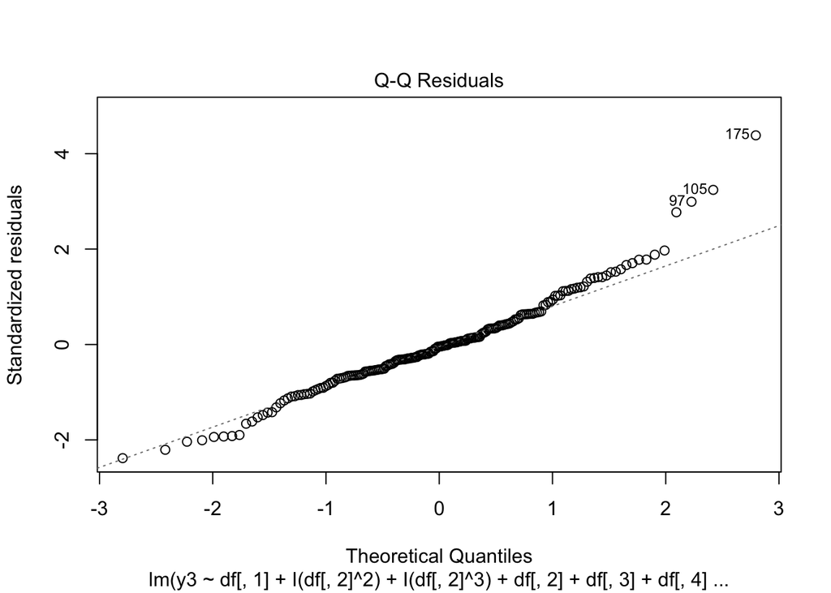

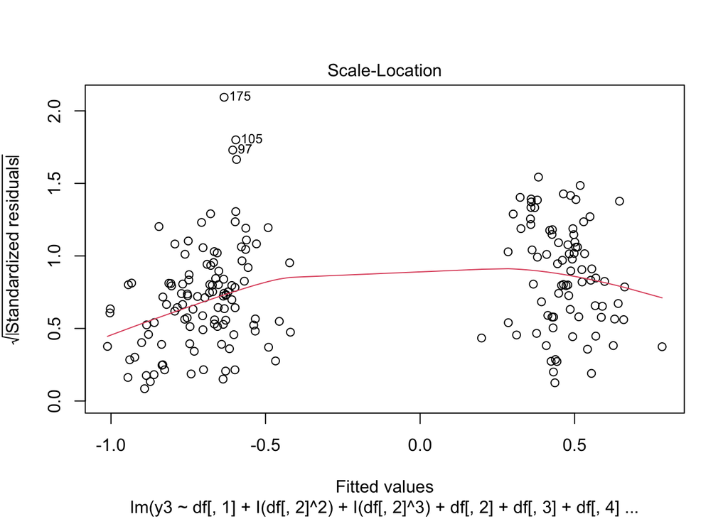

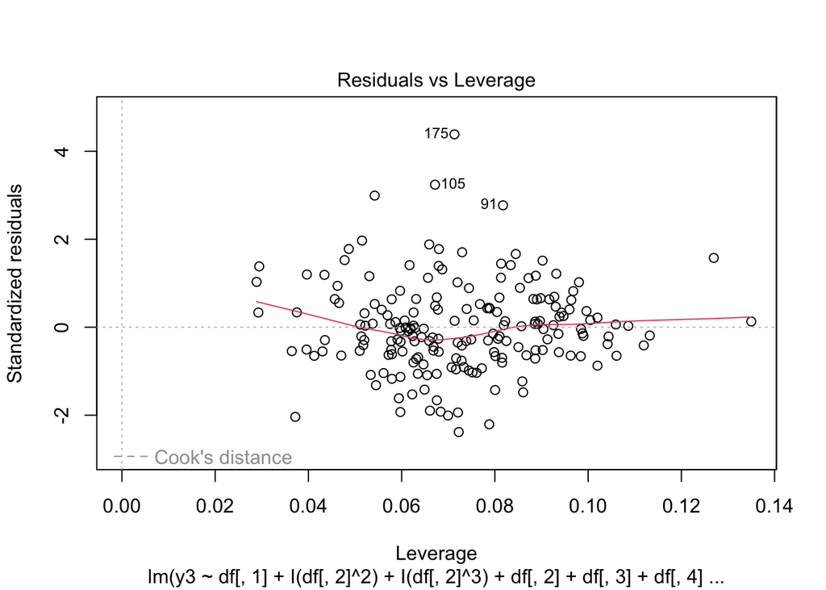

```r
plot(model_cubic)
```

However, for a better model, we want to see a straight red line around 0.

The fact that the points seem to be segmented into two parts might suggest that the variables do not have constant variance, which may be why our model is failing to capture a satisfying relationship (since linear regression works on a constant variance assumption).

```r
df_new <- df_significant[-c(91,97,105),]
y3_new <- y3[-c(91,97,105)]

y3<-c(real_new[[3]])
regression3.2 <-lm(y3_new~., df_new)
summary(regression3.2)
```

```
##
## Call:
## lm(formula = y3_new ~ ., data = df_new)
##
## Residuals:
##      Min       1Q   Median       3Q      Max
## -0.70677 -0.12781 -0.04439  0.14974  1.25533
##
## Coefficients:
##                     Estimate Std. Error t value Pr(>|t|)
## (Intercept)         -1.19776    0.11643 -10.288  < 2e-16 ***
## width.of.patch       0.17300    0.04333   3.993  9.4e-05 ***
## height.of.substrate  1.42274    0.18337   7.759  5.5e-13 ***
## radius.of.the.probe -5.09639    1.80377  -2.825  0.00524 **
## ---
## Signif. codes:  0 '***' 0.001 '**' 0.01 '*' 0.05 '.' 0.1 ' ' 1
##
## Residual standard error: 0.2598 on 186 degrees of freedom
## Multiple R-squared:  0.8438, Adjusted R-squared:  0.8413
## F-statistic: 334.9 on 3 and 186 DF,  p-value: < 2.2e-16
```

The resulting regression performs better when the dimensionality is reduced and the outliers are removed.

```r
model_q2 <- lm(y3_new ~ df_new[,1] + I(df_new[,2]^2)  + df_new[,2] + df_new[,3] , df_new)
summary(model_q2)
```

```
##
## Call:
## lm(formula = y3_new ~ df_new[, 1] + I(df_new[, 2]^2) + df_new[,
##     2] + df_new[, 3], data = df_new)
##
## Residuals:
##      Min       1Q   Median       3Q      Max
## -0.71162 -0.12272 -0.03548  0.13786  1.30650
##
## Coefficients:
##                  Estimate Std. Error t value Pr(>|t|)
## (Intercept)      -1.32674    0.12217 -10.860  < 2e-16 ***
## df_new[, 1]       0.12853    0.04505   2.853  0.00483 **
## I(df_new[, 2]^2) -2.25338    0.76355  -2.951  0.00358 **
## df_new[, 2]       3.48294    0.72085   4.832 2.83e-06 ***
## df_new[, 3]      -4.66900    1.77344  -2.633  0.00919 **
## ---
## Signif. codes:  0 '***' 0.001 '**' 0.01 '*' 0.05 '.' 0.1 ' ' 1
##
## Residual standard error: 0.2546 on 185 degrees of freedom
## Multiple R-squared:  0.8508, Adjusted R-squared:  0.8476
## F-statistic: 263.7 on 4 and 185 DF,  p-value: < 2.2e-16
```

After the adjustment, we do see an improvement of fit in the linear model.

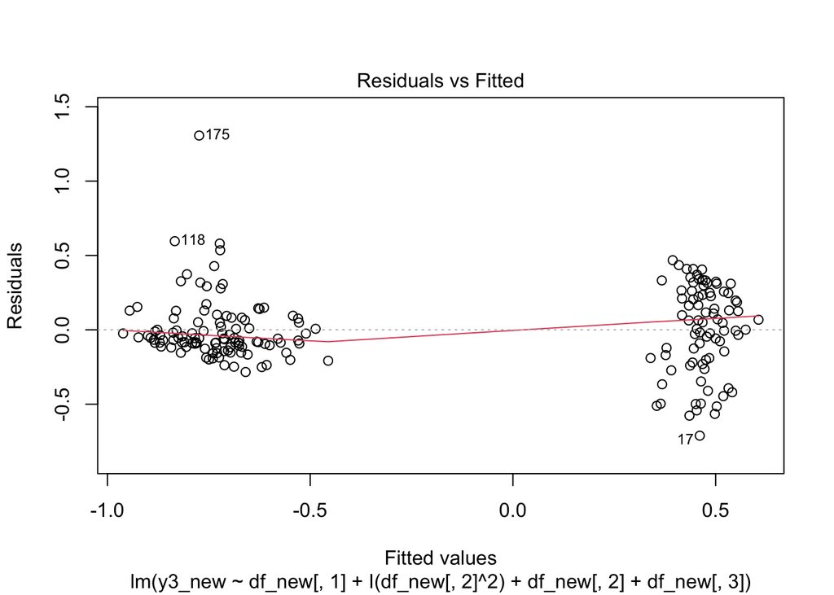

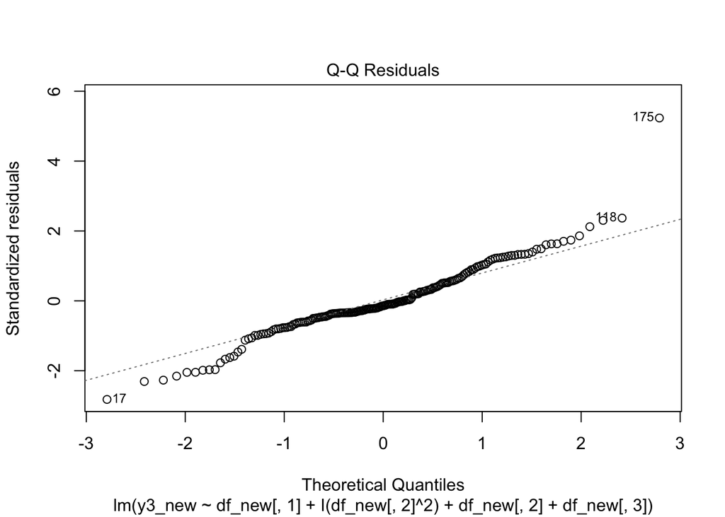

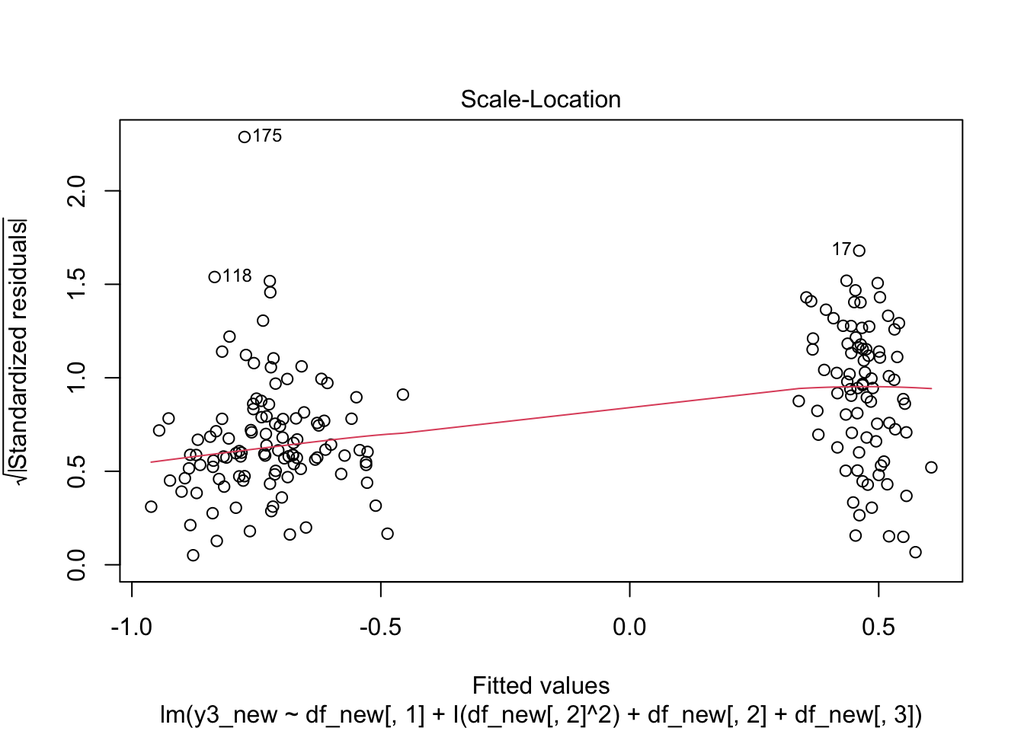

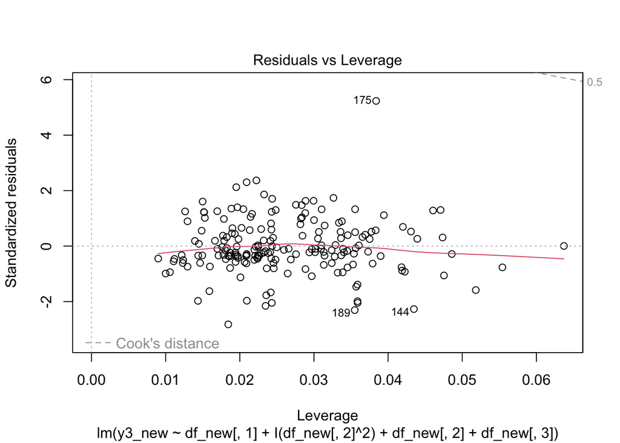

```r
plot(model_q2)
```

*Comparison of methods

Exploratory analysis with PCA was not extremely successful in this case, since it could only reduce the dimensions from 11 to 8 when we tried to preserve approximately 85% of the variance information. This indicates that our data set cannot be reduced in dimension drastically without losing critical information.

The regression analysis with PCA would not have made much of a difference, since for a computer 8 and 11 are not 2 drastically different dimensions. However, if the dimensions and the size of the dataset was larger, we would have preferred to use the PCA reduced model for further analysis.

In the first part where we checked the correlations in pairwise manner, we already concluded that Components 2 and 4 (width of patch and height of substrate) were already strongly and positively correlated. Now that we know they are significant in the determination of our y variable, we can combine them in one variable (maybe using a PCA approximation) to further simplify the model.

Now, let us test the model with the input data that we segmented.

```r
predictions <- predict(model_quad, newdata = df_test)
y3_test<-y3_all[193:385]
# Calculate Mean Squared Error (MSE)
mse <- mean((y3_test - predictions)^2)

# Calculate Mean Absolute Error (MAE)
mae <- mean(abs(y3_test - predictions))

print(paste("MSE:", mse))
```

```
## [1] "MSE: 0.802102520728959"
```

```r
print(paste("MAE:", mae))
```

```
## [1] "MAE: 0.71088326497065"
```

Now, let me consider the imaginary parts of the results. -Linear regression I use the selected columns that I chose in the analysis of real data, to properly detect any variances in fit.

```r
df <- as.data.frame(input_cleaned)
y1<-c(img_new[[1]])
regression1 <-lm(y1~., df_test)
summary(regression1)
```

```
##
## Call:
## lm(formula = y1 ~ ., data = df_test)
##
## Residuals:
##     Min      1Q  Median      3Q     Max
## -1.0502 -0.1810  0.0562  0.2293  0.6803
##
## Coefficients:
##                                            Estimate Std. Error t value Pr(>|t|)
## (Intercept)                                 0.39517    0.26145   1.511  0.13241
## length.of.patch                            -0.02088    0.02605  -0.802  0.42387
## width.of.patch                             -0.01764    0.05568  -0.317  0.75169
## height.of.patch                             0.42201    2.88977   0.146  0.88406
## height.of.substrate                        -0.08398    0.24522  -0.342  0.73238
## height.of.solder.resist.layer               0.25063    1.07997   0.232  0.81675
## radius.of.the.probe                        -1.39075    2.49960  -0.556  0.57863
## c_pad                                      -2.28670    3.61753  -0.632  0.52811
## c_antipad                                  -2.63210    1.25343  -2.100  0.03712
## c_probe                                    -0.22860    0.23487  -0.973  0.33170
## dielectric.constant.of.substrate            0.08966    0.03378   2.654  0.00866
## dielectric.constant.of.solder.resist.layer -0.01233    0.02893  -0.426  0.67038
##
## (Intercept)
## length.of.patch
## width.of.patch
## height.of.patch
## height.of.substrate
## height.of.solder.resist.layer
## radius.of.the.probe
## c_pad
## c_antipad                                  *
## c_probe
## dielectric.constant.of.substrate           **
## dielectric.constant.of.solder.resist.layer
## ---
## Signif. codes:  0 '***' 0.001 '**' 0.01 '*' 0.05 '.' 0.1 ' ' 1
##
## Residual standard error: 0.3472 on 181 degrees of freedom
## Multiple R-squared:  0.07129,    Adjusted R-squared:  0.01485
## F-statistic: 1.263 on 11 and 181 DF,  p-value: 0.2492
```

```r
y2<-c(img_new[[2]])
regression2 <-lm(y2~., df_test)
summary(regression2)
```

```
##
## Call:
## lm(formula = y2 ~ ., data = df_test)
##
## Residuals:
##     Min      1Q  Median      3Q     Max
## -0.9577 -0.2149  0.0768  0.2487  0.5948
##
## Coefficients:
##                                             Estimate Std. Error t value
## (Intercept)                                 0.503470   0.260124   1.935
## length.of.patch                             0.007154   0.025920   0.276
## width.of.patch                             -0.007448   0.055397  -0.134
## height.of.patch                            -2.749362   2.875099  -0.956
## height.of.substrate                         0.190042   0.243975   0.779
## height.of.solder.resist.layer              -0.597744   1.074492  -0.556
## radius.of.the.probe                         0.831507   2.486915   0.334
## c_pad                                      -2.968385   3.599164  -0.825
## c_antipad                                   0.735211   1.247069   0.590
## c_probe                                     0.133689   0.233680   0.572
## dielectric.constant.of.substrate           -0.032024   0.033612  -0.953
## dielectric.constant.of.solder.resist.layer -0.012375   0.028779  -0.430
##                                            Pr(>|t|)
## (Intercept)                                  0.0545 .
## length.of.patch                              0.7829
## width.of.patch                               0.8932
## height.of.patch                              0.3402
## height.of.substrate                          0.4370
## height.of.solder.resist.layer                0.5787
## radius.of.the.probe                          0.7385
## c_pad                                        0.4106
## c_antipad                                    0.5562
## c_probe                                      0.5680
## dielectric.constant.of.substrate             0.3420
## dielectric.constant.of.solder.resist.layer   0.6677
## ---
## Signif. codes:  0 '***' 0.001 '**' 0.01 '*' 0.05 '.' 0.1 ' ' 1
##
## Residual standard error: 0.3454 on 181 degrees of freedom
## Multiple R-squared:  0.02582,    Adjusted R-squared:  -0.03338
## F-statistic: 0.4362 on 11 and 181 DF,  p-value: 0.9381
```

```r
y3<-c(img_new[[3]])
regression3 <-lm(y3~., df_test)
summary(regression3)
```

```
##
## Call:
## lm(formula = y3 ~ ., data = df_test)
##
## Residuals:
##      Min       1Q   Median       3Q      Max
## -1.04018 -0.18769  0.04998  0.23566  0.67830
##
## Coefficients:
##                                            Estimate Std. Error t value Pr(>|t|)
## (Intercept)                                 0.77091    0.26169   2.946  0.00364
## length.of.patch                            -0.01331    0.02608  -0.510  0.61046
## width.of.patch                             -0.03325    0.05573  -0.597  0.55149
## height.of.patch                            -0.87932    2.89244  -0.304  0.76147
## height.of.substrate                         0.33000    0.24545   1.344  0.18048
## height.of.solder.resist.layer              -1.49660    1.08097  -1.384  0.16791
## radius.of.the.probe                         1.28232    2.50191   0.513  0.60890
## c_pad                                      -5.73512    3.62087  -1.584  0.11496
## c_antipad                                   1.78427    1.25459   1.422  0.15669
## c_probe                                     0.09057    0.23509   0.385  0.70049
## dielectric.constant.of.substrate           -0.06305    0.03381  -1.865  0.06384
## dielectric.constant.of.solder.resist.layer -0.02253    0.02895  -0.778  0.43751
##
## (Intercept)                                **
## length.of.patch
## width.of.patch
## height.of.patch
## height.of.substrate
## height.of.solder.resist.layer
## radius.of.the.probe
## c_pad
## c_antipad
## c_probe
## dielectric.constant.of.substrate           .
## dielectric.constant.of.solder.resist.layer
## ---
## Signif. codes:  0 '***' 0.001 '**' 0.01 '*' 0.05 '.' 0.1 ' ' 1
##
## Residual standard error: 0.3475 on 181 degrees of freedom
## Multiple R-squared:  0.06438,    Adjusted R-squared:  0.007514
## F-statistic: 1.132 on 11 and 181 DF,  p-value: 0.3386
```

```r
y4<-c(img_new[[4]])
regression4 <-lm(y4~., df_test)
summary(regression4)
```

```
##
## Call:
## lm(formula = y4 ~ ., data = df_test)
##
## Residuals:
##     Min      1Q  Median      3Q     Max
## -1.0040 -0.1840  0.0333  0.2526  0.5668
##
## Coefficients:
##                                             Estimate Std. Error t value
## (Intercept)                                 0.909358   0.259940   3.498
## length.of.patch                            -0.036128   0.025902  -1.395
## width.of.patch                             -0.066112   0.055358  -1.194
## height.of.patch                            -0.995155   2.873066  -0.346
## height.of.substrate                         0.512178   0.243803   2.101
## height.of.solder.resist.layer              -1.158339   1.073732  -1.079
## radius.of.the.probe                        -0.645189   2.485156  -0.260
## c_pad                                      -8.610242   3.596620  -2.394
## c_antipad                                   1.770779   1.246187   1.421
## c_probe                                     0.095767   0.233514   0.410
## dielectric.constant.of.substrate           -0.069516   0.033588  -2.070
## dielectric.constant.of.solder.resist.layer  0.005504   0.028759   0.191
##                                            Pr(>|t|)
## (Intercept)                                0.000589 ***
## length.of.patch                            0.164788
## width.of.patch                             0.233942
## height.of.patch                            0.729464
## height.of.substrate                        0.037045 *
## height.of.solder.resist.layer              0.282114
## radius.of.the.probe                        0.795454
## c_pad                                      0.017688 *
## c_antipad                                  0.157049
## c_probe                                    0.682209
## dielectric.constant.of.substrate           0.039903 *
## dielectric.constant.of.solder.resist.layer 0.848434
## ---
## Signif. codes:  0 '***' 0.001 '**' 0.01 '*' 0.05 '.' 0.1 ' ' 1
##
## Residual standard error: 0.3452 on 181 degrees of freedom
## Multiple R-squared:  0.09383,    Adjusted R-squared:  0.03876
## F-statistic: 1.704 on 11 and 181 DF,  p-value: 0.0755
```

The obtained R-squared values are very very low, indicating a weaker relationship with the input variables. Therefore, the model where we use the real parts of the results is preferred.

```r
cor(real_new,img_new)
```

```
##              X0        X158       X178       X200
## X0   0.03719248 -0.48138129 -0.4882243 -0.5039089
## X158 0.20141094 -0.34087739 -0.5544068 -0.6399218
## X178 0.17770448 -0.15337430 -0.3524416 -0.5937108
## X200 0.15387410 -0.07902579 -0.1272788 -0.3957356
```

In the preparation of this report, I got help from ChatGPT regarding the syntax of the language and understanding of the graphical outputs.